# Possible to-do's and discussion points:

1. Which annotations to keep?
2. Should we treshold based on the total allele number?
- Add alpha7 dup
- Check H267 and E270 from GABRB3

# GnomAD analysis

## Library import

```python
from pathlib import Path
import os
import pandas
```

```python
from Bio import AlignIO
from Bio.Seq import Seq
from Bio.SeqUtils import seq1
```

```python
from matplotlib import pyplot
import matplotlib
%matplotlib inline
matplotlib.style.use("ggplot")
matplotlib.rcParams["figure.figsize"] = (10, 10)
```

```python
import plotly.express as px
```

## Importing the files

The raw files come in two sets. One is from GnomAD v3 and the other from GnomAD v2. The second is present as a backup if the mapping to the protein sequence from v3 fails.

```python
_folder_path = Path() / "Raw_data"
_raw_files = [x for x in os.listdir(_folder_path) if os.path.isfile(_folder_path / x)]
_alternative_raw = [file for file in _raw_files if "2.1.1" in file]
_raw_files = list(set(_raw_files) - set(_alternative_raw))
print(*_raw_files, sep="\n")
```

```
gnomAD_v3.1.1_ENSG00000166206_2021_08_25_17_51_44_GABRB3.csv
gnomAD_v3.1.1_ENSG00000111886_2021_08_25_17_54_36_GABRR2.csv
gnomAD_v3.1.1_ENSG00000101958_2021_08_26_22_07_30_GLRA2.csv
gnomAD_v3.1.2_ENSG00000174343_2021_10_26_19_00_26_CHRNA9.csv
gnomAD_v3.1.1_ENSG00000187730_2021_08_25_17_55_11_GABRD.csv
gnomAD_v3.1.1_ENSG00000120903_2021_09_06_14_23_00_CHRNA2.csv
gnomAD_v3.1.1_ENSG00000146276_2021_08_25_17_54_23_GABRR1.csv
gnomAD_v3.1.2_ENSG00000129749_2021_10_26_19_01_13_CHRNA10.csv
gnomAD_v3.1.1_ENSG00000102287_2021_08_25_17_51_00_GABRE.csv
gnomAD_v3.1.1_ENSG00000163285_2021_08_25_17_51_58_GABRG1.csv
gnomAD_v3.1.1_ENSG00000169684_2021_09_06_15_12_03_CHRNA5.csv
gnomAD_v3.1.1_ENSG00000101204_2021_09_06_14_25_11_CHRNA4.csv
gnomAD_v3.1.1_ENSG00000183185_2021_08_25_17_54_54_GABRR3.csv
gnomAD_v3.1.1_ENSG00000186090_2021_08_25_17_57_26_5HT3D.csv
gnomAD_v3.1.1_ENSG00000163288_2021_08_25_17_51_16_GABRB1.csv
gnomAD_v3.1.1_ENSG00000138435_2021_08_26_22_09_48_CHRNA1.csv
gnomAD_v3.1.1_ENSG00000109158_2021_08_25_17_49_50_GABRA4.csv
gnomAD_v3.1.1_ENSG00000186297_2021_08_25_17_50_11_GABRA5.csv
gnomAD_v3.1.1_ENSG00000151834_2021_08_25_17_49_15_GABRA2.csv
gnomAD_v3.1.2_ENSG00000196811_2021_10_26_19_04_10_CHRNG.csv
gnomAD_v3.1.2_ENSG00000117971_2021_10_26_19_03_47_CHRNB4.csv
gnomAD_v3.1.2_ENSG00000135902_2021_10_26_19_04_55_CHRND.csv
gnomAD_v3.1.1_ENSG00000145863_2021_08_25_17_50_27_GABRA6.csv
gnomAD_v3.1.1_ENSG00000138435_2021_09_06_14_24_13_CHRNA1.csv
gnomAD_v3.1.1_ENSG00000094755_2021_08_25_17_53_59_GABRP.csv
gnomAD_v3.1.1_ENSG00000109738_2021_08_26_22_08_17_GLRB.csv
gnomAD_v3.1.1_ENSG00000022355_2021_08_25_17_45_26_GABRA1.csv
gnomAD_v3.1.1_ENSG00000149305_2021_08_25_17_56_50_5HT3B.csv
gnomAD_v3.1.2_ENSG00000147432_2021_10_26_19_03_23_CHRNB3.csv
gnomAD_v3.1.1_ENSG00000186919_2021_08_26_22_05_56_ZACN.csv
gnomAD_v3.1.1_ENSG00000268089_2021_08_25_17_55_33_GABRQ.csv
gnomAD_v3.1.1_ENSG00000113327_2021_08_25_17_52_13_GABRG2.csv
gnomAD_v3.1.1_ENSG00000120903_2021_08_26_22_10_13_CHRNA2.csv
gnomAD_v3.1.1_ENSG00000145451_2021_08_26_22_07_54_GLRA3.csv
gnomAD_v3.1.1_ENSG00000145864_2021_08_25_17_51_32_GABRB2.csv
gnomAD_v3.1.1_ENSG00000145888_2021_08_26_22_07_00_GLRA1.csv
gnomAD_v3.1.1_ENSG00000182256_2021_08_25_17_52_30_GABRG3.csv
gnomAD_v3.1.2_ENSG00000160716_2021_10_26_19_03_04_CHRNB2.csv
gnomAD_v3.1.2_ENSG00000170175_2021_10_26_19_02_38_CHRNB1.csv
gnomAD_v3.1.1_ENSG00000186038_2021_08_25_17_57_43_5HT3E.csv
gnomAD_v3.1.1_ENSG00000080644_2021_09_06_14_22_08_CHRNA3.csv
gnomAD_v3.1.1_ENSG00000011677_2021_08_25_17_49_37_GABRA3.csv
gnomAD_v3.1.1_ENSG00000147434_2021_09_06_15_12_26_CHRNA6.csv
gnomAD_v3.1.1_ENSG00000178084_2021_08_25_17_57_07_5HT3C.csv
gnomAD_v3.1.1_ENSG00000166736_2021_08_25_17_56_29_5HT3A.csv
gnomAD_v3.1.2_ENSG00000108556_2021_10_26_19_05_18_CHRNE.csv
gnomAD_v3.1.2_ENSG00000175344_2021_10_26_18_59_04_CHRNA7.csv
```

We import the files as pandas DataFrame and add a column in which we track the gene of interest.

```python
data = []
for file in _raw_files:
    data.append(pandas.read_csv(_folder_path / file))
    data[-1]["Gene"] = file.split(".")[-2].split("_")[-1]
data_alternative = []
for file in _alternative_raw:
    data_alternative.append(pandas.read_csv(_folder_path / file))
    data_alternative[-1]["Gene"] = file.split(".")[-2].split("_")[-1]
```

```python
data[0]
```

|  | Chromosome | Position | rsIDs | Reference | Alternate | Source | Filters - exomes | Filters - genomes | HGVS Consequence | Protein Consequence | ... | Hemizygote Count Ashkenazi Jewish | Allele Count African/African-American | Allele Number African/African-American | Homozygote Count African/African-American | Hemizygote Count African/African-American | Allele Count European (non-Finnish) | Allele Number European (non-Finnish) | Homozygote Count European (non-Finnish) | Hemizygote Count European (non-Finnish) | Gene |
| --- | --- | --- | --- | --- | --- | --- | --- | --- | --- | --- | --- | --- | --- | --- | --- | --- | --- | --- | --- | --- | --- |
| 0 | 15 | 26547721 | rs1399789878 | T | C | gnomAD Genomes | NaN | PASS | c.*72A>G | NaN | ... | 0 | 0 | 41434 | 0 | 0 | 1 | 68046 | 0 | 0 | GABRB3 |
| 1 | 15 | 26547735 | rs1339022205 | G | A | gnomAD Genomes | NaN | PASS | c.*58C>T | NaN | ... | 0 | 0 | 41410 | 0 | 0 | 1 | 68018 | 0 | 0 | GABRB3 |
| 2 | 15 | 26547736 | rs1295790024 | C | A | gnomAD Genomes | NaN | PASS | c.*57G>T | NaN | ... | 0 | 1 | 41366 | 0 | 0 | 0 | 68004 | 0 | 0 | GABRB3 |
| 3 | 15 | 26547743 | rs1245566888 | A | G | gnomAD Genomes | NaN | PASS | c.*50T>C | NaN | ... | 0 | 1 | 41442 | 0 | 0 | 1 | 68048 | 0 | 0 | GABRB3 |
| 4 | 15 | 26547744 | rs1267782073 | T | C | gnomAD Genomes | NaN | PASS | c.*49A>G | NaN | ... | 0 | 0 | 41456 | 0 | 0 | 1 | 68044 | 0 | 0 | GABRB3 |
| ... | ... | ... | ... | ... | ... | ... | ... | ... | ... | ... | ... | ... | ... | ... | ... | ... | ... | ... | ... | ... | ... |
| 847 | 15 | 26939493 | rs563174099 | G | C | gnomAD Genomes | NaN | PASS | c.-57C>G | NaN | ... | 0 | 0 | 41430 | 0 | 0 | 0 | 68034 | 0 | 0 | GABRB3 |
| 848 | 15 | 26939497 | NaN | C | T | gnomAD Genomes | NaN | PASS | c.-61G>A | NaN | ... | 0 | 1 | 41436 | 0 | 0 | 0 | 68036 | 0 | 0 | GABRB3 |
| 849 | 15 | 26939498 | NaN | A | T | gnomAD Genomes | NaN | PASS | c.-62T>A | NaN | ... | 0 | 1 | 41252 | 0 | 0 | 0 | 67956 | 0 | 0 | GABRB3 |
| 850 | 15 | 26939505 | rs970966776 | T | A | gnomAD Genomes | NaN | PASS | c.-69A>T | NaN | ... | 0 | 2 | 41428 | 0 | 0 | 0 | 68022 | 0 | 0 | GABRB3 |
| 851 | 15 | 26939509 | rs1343566141 | G | C | gnomAD Genomes | NaN | PASS | c.-73C>G | NaN | ... | 0 | 1 | 41436 | 0 | 0 | 0 | 68028 | 0 | 0 | GABRB3 |

852 rows × 61 columns

Some columns are present only in a subset of files. We will keep them when joining the datasets, and introduce NaN where we have no data.

[figure not shown]

```python
pyplot.hist([len(x.columns) for x in data])
pyplot.xlabel("VEP Annotation")
pyplot.ylabel("Fraction of the total dataset")
pyplot.title("Distribution of classifications in the dataset")
pyplot.show()
```

## Joining the datasets

We join both the main dataset and the alternative one.

```python
dataset = pandas.concat(data, axis=0, join="outer", ignore_index=True)
dataset_alternative = pandas.concat(data_alternative, axis=0, join="outer", ignore_index=True)
```

```python
dataset.shape
```

```
(28738, 62)
```

## Exploring the total dataset

### Different polymorphism annotations

For a complete description of the effect annotations see [the ensembl description](https://www.ensembl.org/info/genome/variation/prediction/predicted_data.html). Only a subset of all the possible annotations is present. Here we focus only on the ones that result in a difference in the protein product. We collect the annotation labels into a list we can invoke later on.

```python
dataset["VEP Annotation"].unique()
```

```
array(['3_prime_UTR_variant', 'missense_variant', 'synonymous_variant',
       'intron_variant', 'splice_region_variant', 'splice_donor_variant',
       'stop_gained', '5_prime_UTR_variant', 'splice_acceptor_variant',
       'inframe_insertion', 'start_lost', 'frameshift_variant',
       'stop_lost', 'inframe_deletion', 'stop_retained_variant',
       'protein_altering_variant', nan], dtype=object)
```

```python
_VEPs = ["missense_variant",
         "stop_gained",
         "splice_acceptor_variant",
         "splice_donor_variant",
         "frameshift_variant",
         "inframe_deletion",
         "inframe_insertion",
         "start_lost",
         "stop_lost",
         "protein_altering_variant"]
```

We see that the majority of the mutations of interest get classified into missense mutations (note that the visuals below only look at the labels of interest; though in the first graph the proportion is normalized to the size of the whole dataset, in the pie chart the total is equal to the number of the mutations of interest). As such, it might make sense to discuss if we would be better off disregarding all the other types of mutations just to make our life easier in terms of the analysis. In any event the proportions of different mutation types should probably be shown.

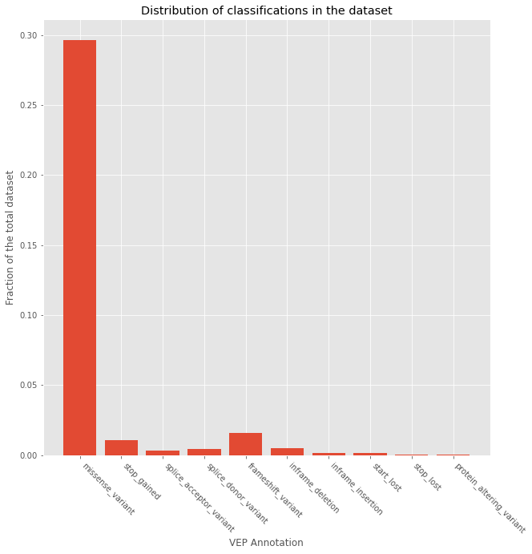

```python
pyplot.bar(_VEPs, [sum(dataset["VEP Annotation"] == x)/dataset.shape[0]  for x in _VEPs])
pyplot.xticks(rotation=-45, horizontalalignment="left")
pyplot.xlabel("VEP Annotation")
pyplot.ylabel("Fraction of the total dataset")
pyplot.title("Distribution of classifications in the dataset")
pyplot.show()
```

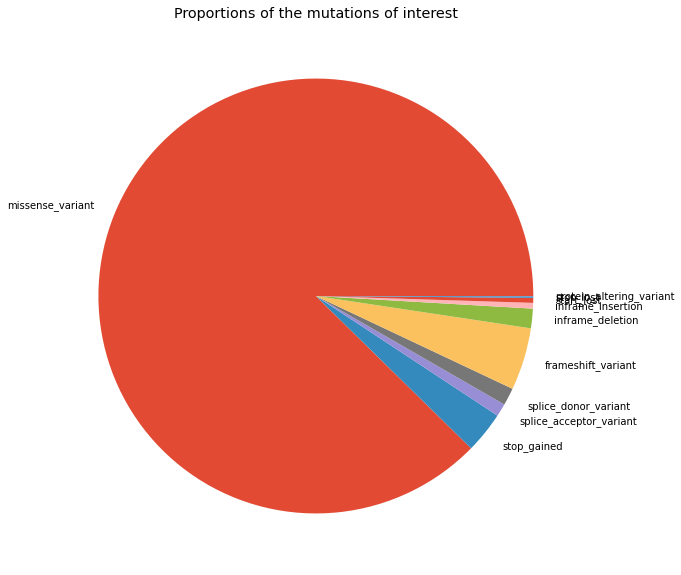

```python
_counts = [sum(dataset["VEP Annotation"] == x)  for x in _VEPs]
_total = sum(_counts)
_counts = [x/_total for x in _counts]
pyplot.pie(_counts, labels=_VEPs)
pyplot.title("Proportions of the mutations of interest")
pyplot.show()
```

## Filtering

Before filtering anything else, we will discard all the data points where the total allele number deviates too much.

```python
matplotlib.rcParams["figure.figsize"] = (30, 10)
```

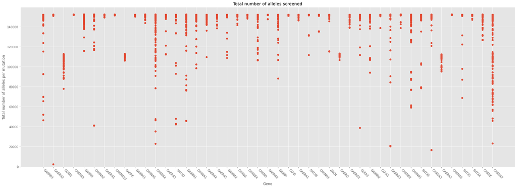

```python
pyplot.scatter(dataset["Gene"], dataset["Allele Number"])
pyplot.xticks(rotation=-45, horizontalalignment="left")
pyplot.xlabel("Gene")
pyplot.ylabel("Total number of alleles per mutation")
pyplot.title("Total number of alleles screened")
ax = pyplot.gca()
ax.set_ylim([0, None])
pyplot.show()
```

```python
_mean_af = dataset["Allele Number"].mean()
_std_af = dataset["Allele Number"].std()
print(f"Mean: {_mean_af}\nS. dev.: {_std_af}")
```

```
Mean: 148916.9469892099
S. dev.: 11639.162625345753
```

```python
dataset = dataset[dataset.apply(lambda x: abs(x["Allele Number"] - _mean_af) < 3*_std_af, axis=1)]
```

Let's check again how the distribution looks like.

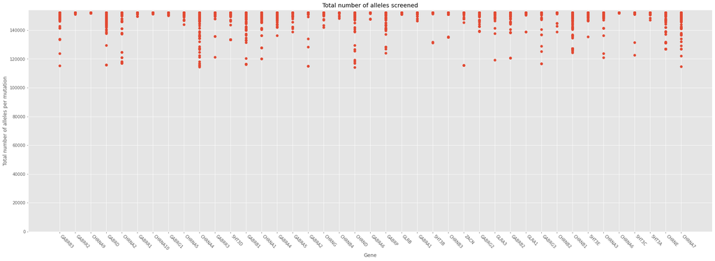

```python
pyplot.scatter(dataset["Gene"], dataset["Allele Number"])
pyplot.xticks(rotation=-45, horizontalalignment="left")
pyplot.xlabel("Gene")
pyplot.ylabel("Total number of alleles per mutation")
pyplot.title("Total number of alleles screened")
ax = pyplot.gca()
ax.set_ylim([0, None])
pyplot.show()
```

We filter only for the GnomAD data.

```python
dataset = dataset[dataset["Source"] == "gnomAD Genomes"]
dataset.reset_index(inplace=True)
```

```python
matplotlib.rcParams["figure.figsize"] = (10, 10)
```

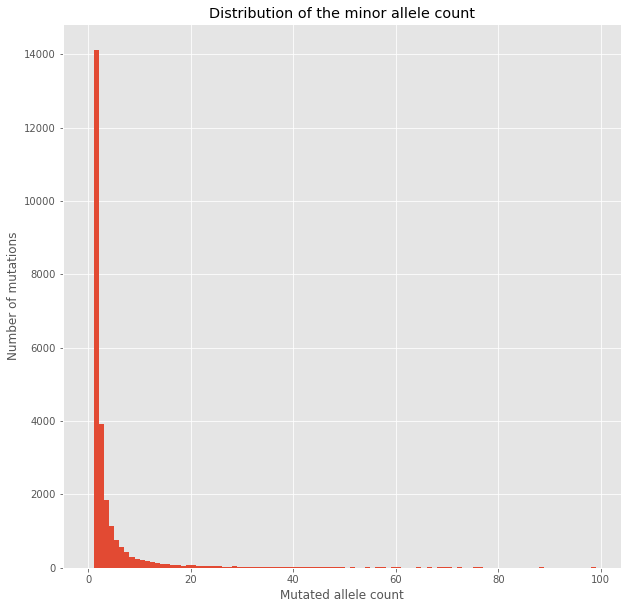

```python
pyplot.hist(dataset["Allele Count"], bins=[x for x in range(0, 100)])
pyplot.xlabel("Mutated allele count")
pyplot.ylabel("Number of mutations")
pyplot.title("Distribution of the minor allele count")
pyplot.show()
```

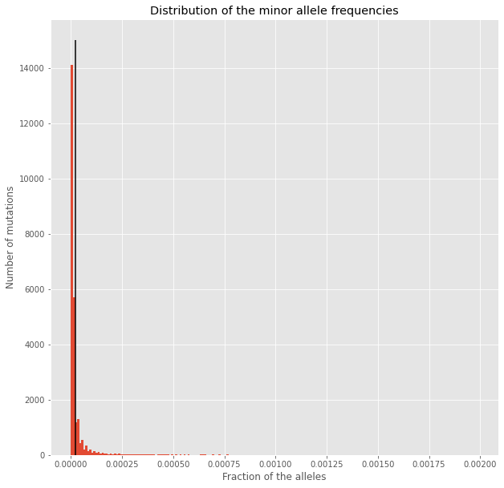

```python
pyplot.hist(dataset["Allele Count"]/dataset["Allele Number"], bins=[x*0.00001 for x in range(0, 200)])
pyplot.vlines([0.00002], ymin=0, ymax=15000, colors="black")
pyplot.xlabel("Fraction of the alleles")
pyplot.ylabel("Number of mutations")
pyplot.title("Distribution of the minor allele frequencies")
pyplot.show()
```

```python
subdata = dataset[dataset["Allele Count"]/dataset["Allele Number"] > 0.00002]
subdata = subdata[subdata["VEP Annotation"].isin(_VEPs)]
subdata
```

|  | index | Chromosome | Position | rsIDs | Reference | Alternate | Source | Filters - exomes | Filters - genomes | HGVS Consequence | ... | Allele Count African/African-American | Allele Number African/African-American | Homozygote Count African/African-American | Hemizygote Count African/African-American | Allele Count European (non-Finnish) | Allele Number European (non-Finnish) | Homozygote Count European (non-Finnish) | Hemizygote Count European (non-Finnish) | Gene | Transcript |
| --- | --- | --- | --- | --- | --- | --- | --- | --- | --- | --- | --- | --- | --- | --- | --- | --- | --- | --- | --- | --- | --- |
| 15 | 15 | 15 | 26547873.0 | rs377215030 | T | C | gnomAD Genomes | NaN | PASS | p.Ile448Val | ... | 0.0 | 41464.0 | 0.0 | 0.0 | 3.0 | 68040.0 | 0.0 | 0.0 | GABRB3 | NaN |
| 31 | 31 | 15 | 26547946.0 | rs76962261 | G | C | gnomAD Genomes | NaN | PASS | p.His423Gln | ... | 0.0 | 41428.0 | 0.0 | 0.0 | 0.0 | 68046.0 | 0.0 | 0.0 | GABRB3 | NaN |
| 33 | 33 | 15 | 26547950.0 | rs369631109 | G | A | gnomAD Genomes | NaN | PASS | p.Pro422Leu | ... | 2.0 | 41418.0 | 0.0 | 0.0 | 2.0 | 68036.0 | 0.0 | 0.0 | GABRB3 | NaN |
| 40 | 40 | 15 | 26548011.0 | rs185383468 | A | G | gnomAD Genomes | NaN | PASS | p.Tyr402His | ... | 0.0 | 41446.0 | 0.0 | 0.0 | 0.0 | 68028.0 | 0.0 | 0.0 | GABRB3 | NaN |
| 41 | 41 | 15 | 26548056.0 | rs373823173 | C | T | gnomAD Genomes | NaN | PASS | p.Asp387Asn | ... | 2.0 | 41442.0 | 0.0 | 0.0 | 2.0 | 68034.0 | 0.0 | 0.0 | GABRB3 | NaN |
| ... | ... | ... | ... | ... | ... | ... | ... | ... | ... | ... | ... | ... | ... | ... | ... | ... | ... | ... | ... | ... | ... |
| 26842 | 28728 | 15 | 32168131.0 | rs763601936 | C | T | gnomAD Genomes | NaN | PASS | p.Arg296Cys | ... | 0.0 | 41152.0 | 0.0 | 0.0 | 5.0 | 67548.0 | 0.0 | 0.0 | CHRNA7 | ENST00000635884.1 |
| 26843 | 28729 | 15 | 32168132.0 | rs1296944199 | G | A | gnomAD Genomes | NaN | PASS | p.Val395Met | ... | 9.0 | 41090.0 | 0.0 | 0.0 | 1.0 | 67446.0 | 0.0 | 0.0 | CHRNA7 | ENST00000306901.9 |
| 26845 | 28731 | 15 | 32168154.0 | rs936211684 | A | G | gnomAD Genomes | NaN | PASS | p.Asp402Gly | ... | 1.0 | 40198.0 | 0.0 | 0.0 | 0.0 | 66232.0 | 0.0 | 0.0 | CHRNA7 | ENST00000306901.9 |
| 26848 | 28734 | 15 | 32168187.0 | rs1343650360 | C | A | gnomAD Genomes | NaN | PASS | p.Ser413Tyr | ... | 6.0 | 38280.0 | 0.0 | 0.0 | 0.0 | 64888.0 | 0.0 | 0.0 | CHRNA7 | ENST00000306901.9 |
| 26849 | 28735 | 15 | 32168259.0 | rs1291343905 | TGGA | T | gnomAD Genomes | NaN | PASS | p.Glu439del | ... | 0.0 | 35018.0 | 0.0 | 0.0 | 1.0 | 63464.0 | 0.0 | 0.0 | CHRNA7 | ENST00000306901.9 |

2174 rows × 63 columns

If we look at the distribution of mutations across the annotation labels as before, we see that the distribution has become even more skewed towards the missense variants.

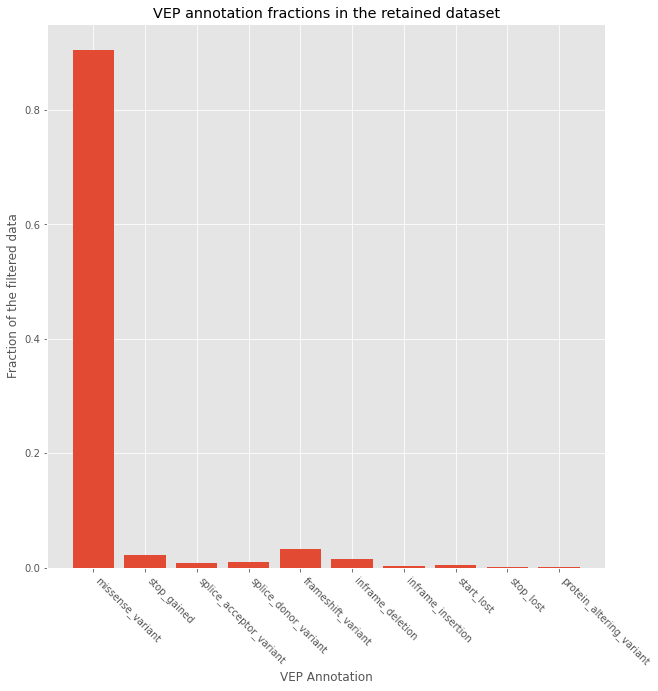

```python
pyplot.bar(_VEPs, [sum(subdata["VEP Annotation"] == x)/subdata.shape[0]  for x in _VEPs])
pyplot.xticks(rotation=-45, horizontalalignment="left")
pyplot.xlabel("VEP Annotation")
pyplot.ylabel("Fraction of the filtered data")
pyplot.title("VEP annotation fractions in the retained dataset")
pyplot.show()
```

## Distribution across the genes

First we just look at the number of different polymorphisms detected for each gene.

```python
matplotlib.rcParams["figure.figsize"] = (30, 10)
```

```python
_genes = subdata["Gene"].unique()
_values = pandas.DataFrame({"Gene": _genes, "Value": [sum(subdata["Gene"] == x)/subdata.shape[0]  for x in _genes]})
_values.sort_values(by="Value", ascending=False, inplace=True, ignore_index=True)
```

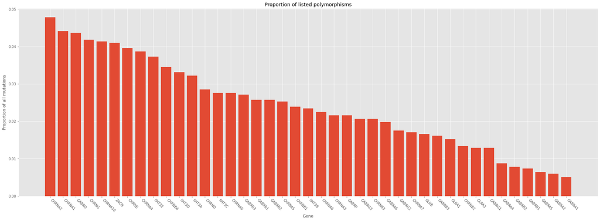

```python
pyplot.bar(_values["Gene"], _values["Value"])
pyplot.xticks(rotation=-45, horizontalalignment="left")
pyplot.xlabel("Gene")
pyplot.ylabel("Proportion of all mutations")
pyplot.title("Proportion of listed polymorphisms")
pyplot.show()
```

We might want to discard some samples where total allele number is lower than some set treshold, as these might become the possible outliers in later statistics.

Next we look at the allele counts across all the mutations for single genes to get a feeling for which genes drive the statistical power in our sample.

```python
_values["Allele Count"] = [sum(subdata["Allele Count"][subdata["Gene"] == x]) for x in _values["Gene"]]
_values.sort_values(by="Allele Count", ascending=False, inplace=True, ignore_index=True)
```

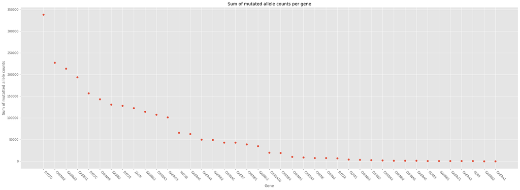

```python
pyplot.scatter(_values["Gene"], _values["Allele Count"])
pyplot.xticks(rotation=-45, horizontalalignment="left")
pyplot.xlabel("Gene")
pyplot.ylabel("Sum of mutatted allele counts")
pyplot.title("Sum of mutated allele counts per gene")
pyplot.show()
```

## Extracting the AA number from missense variants

We then look at the relative positions of the mutations for each gene separately by plotting the histograms one by one.

```python
missense = subdata[subdata["VEP Annotation"] == "missense_variant"]
missense["AA Number"] = missense["Protein Consequence"].str.extract(r"[a-zA-Z]([0-9]+)[a-zA-Z]").astype("int32")
missense.reset_index(inplace=True)
```

```python
missense["AA Relative"] = 0
# Lengths are taken from UniProt
lengths = {
    "GABRA3": 492,
    "GABRA1": 456,
    "CHRNA3": 505,
    "GABRP": 440,
    "CHRNA4": 627,
    "GLRA2": 452,
    "GABRE": 506,
    "GABRA4": 554,
    "GLRB": 497,
    "GABRR2": 465,
    "GABRG2": 467,
    "CHRNA2": 529,
    "CHRNA1": 482,
    "GLRA3": 464,
    "GABRA6": 453,
    "GABRB2": 512,
    "GLRA1": 457,
    "GABRR1": 479,
    "CHRNA6": 494,
    "5HT3B": 441,
    "GABRA2": 451,
    "GABRG1": 465,
    "GABRB1": 474,
    "GABRB3": 473,
    "5HT3A": 478,
    "CHRNA5": 468,
    "5HT3C": 447,
    "GABRG3": 467,
    "GABRR3": 467,
    "5HT3E": 456,
    "5HT3D": 454,
    "GABRA5": 462,
    "ZACN": 412,
    "GABRD": 452,
    "GABRQ": 632,
    "CHRNE": 493,
    "CHRNB4": 498,
    "CHRNA10": 450,
    "CHRND": 517,
    "CHRNB3": 458,
    "CHRNB2": 502,
    "CHRNB1": 501,
    "CHRNA9": 479,
    "CHRNA7": 502,
    "CHRNG": 517,
}
for gene in missense["Gene"].unique():
    missense["AA Relative"][missense["Gene"] == gene] = missense["AA Number"][missense["Gene"] == gene] / lengths[gene]
```

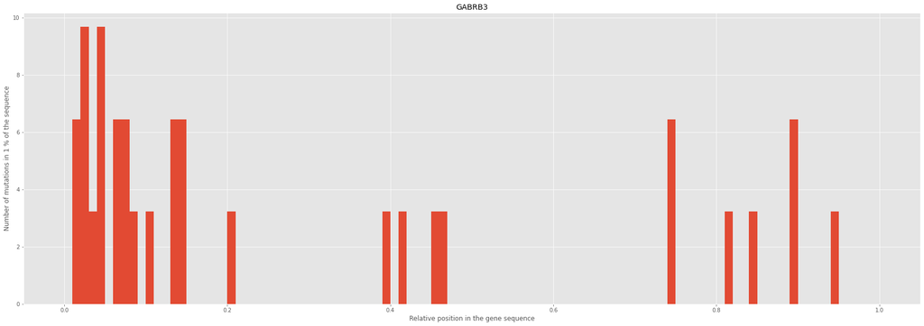

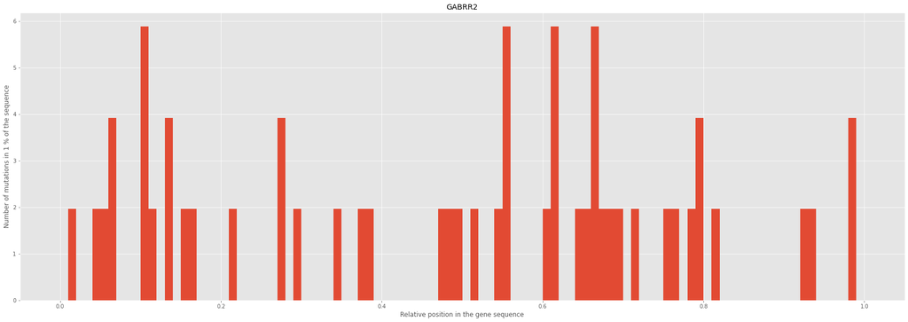

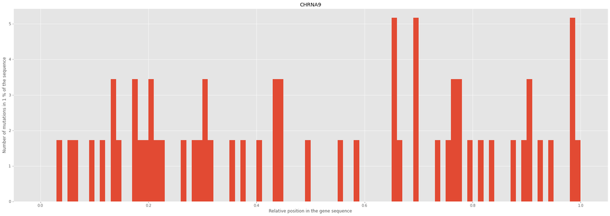

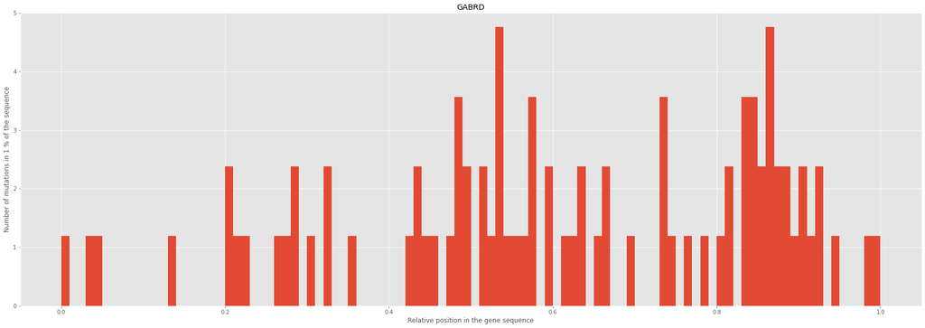

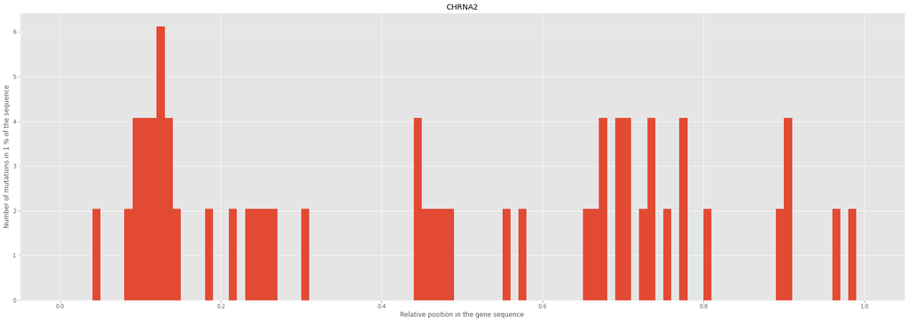

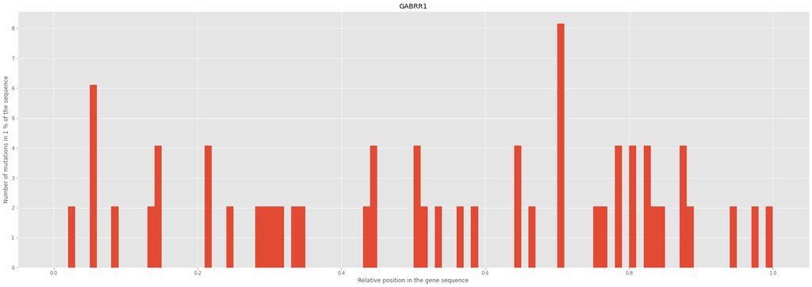

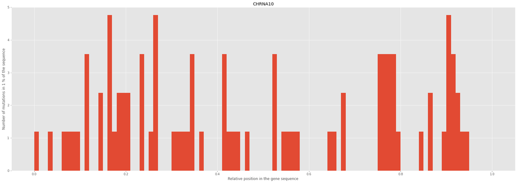

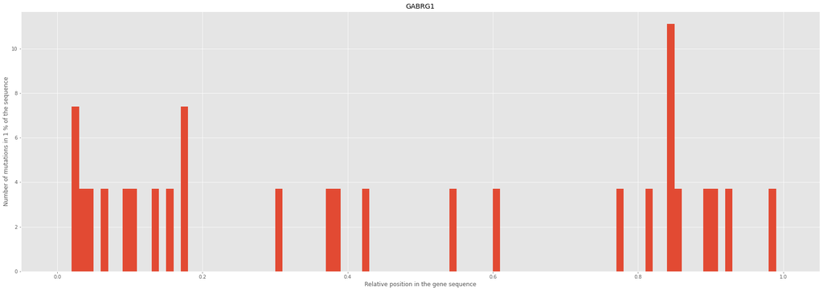

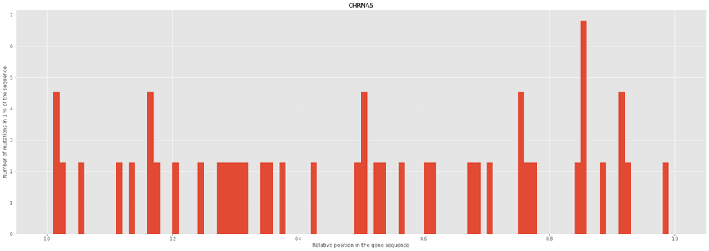

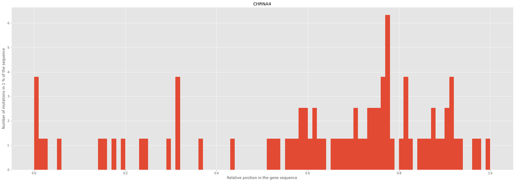

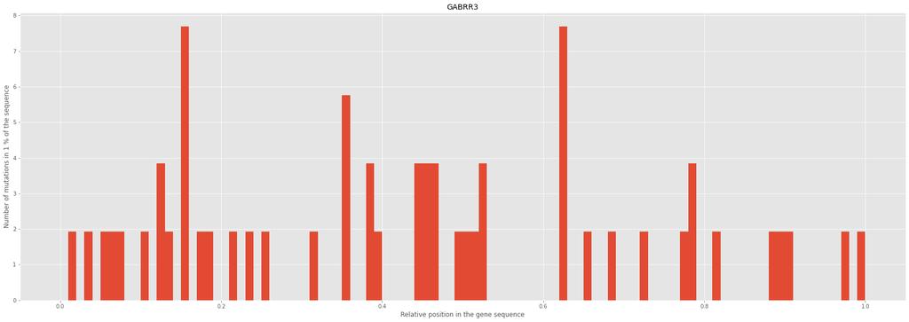

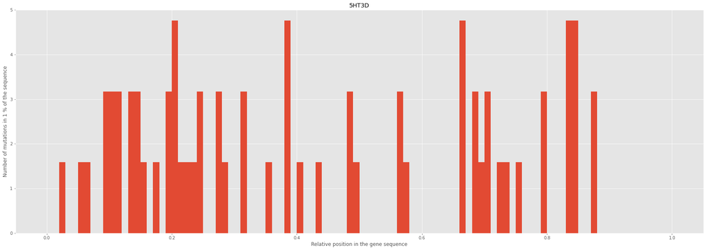

[29 more figures not shown]

```python
for gene in missense["Gene"].unique():
    pyplot.hist(missense["AA Relative"][missense["Gene"] == gene], bins=[x*0.01 for x in range(0, 101)], density=True)
    pyplot.xlabel("Relative position in the gene sequence")
    pyplot.ylabel("Number of mutations in 1 % of the sequence")
    pyplot.title(gene)
    pyplot.show()
```